# CHES dataset

4/9/2021

Aquest exercici de la PAC consisteix en un treball en grup en què heu de descriure una base de dades i generar alguns gràfics amb les dades.

- Per començar, genereu el document Html amb el botó Knitr i llegiu detingudament aquestes instruccions.
- Aquest RMarkdown consta de tres apartats: Introducció, País i Eixos. L’apartat Introducció i l’apartat del País l’haureu d’escriure conjuntament en grup. A l’apartat Eixos, cada estudiant haurà de triar un eix ideològic i de manera individual haurà de generar un gràfic i descriure’n el contingut.
- Elimineu totes les instruccions de manera que al final només genereu l’Html amb el vostre treball.
- L’objectiu és que el grup generi un **únic treball**, publicat en Html a la xarxa mitjançant [RPubs](https://rpubs.com/).
- Un cop tingueu el Rmd omplert i hagueu generat l’Html al Viewer, cliqueu a l’icona blava del Viewer (Publish -> Publish a Document) i seleccioneu RPubs.
- Només cal que un estudiant generi l’Html RPubs. L’estudiant en qüestió compartirà la direcció web amb la resta d’estudiants del grup. Cada estudiant adjuntarà la direcció web de l’RPubs a l’apartat corresponent de la PAC. NOMÉS caldrà ubicar-hi l’adreça web.

## Introducció

El codi següent un genera un marc de dades:

- Haureu de canviar el número del país (1 = Bèlgica) pel número del vostre grup per visualitzar les dades del país que us correspon.
- Per informació del país, els partits polítics i les variables del marc de dades, consulteu el [llibre de codis](https://static1.squarespace.com/static/5975c9bfdb29d6a05c65209b/t/5fa04ec05d3c8218b7c91450/1604341440585/2019_CHES_codebook.pdf) i el [qüestionari](https://static1.squarespace.com/static/5975c9bfdb29d6a05c65209b/t/5ed3029fe080e33f639e6e9a/1590887075513/CHES_UK_Qualtrics.pdf).
- Si voleu, elimineu el # a select i introduïu-hi el nom de les variables que us vulgueu incloure en el marc dades.
- Feu una descripció de les dades que apareixen a la taula. **Màxim 250 paraules**.

```r
ches %>%
  filter(country == 1) %>%
# select(party, euposition) %>%
  head(15) %>%
  DT::datatable(ches)
```

|  | country | eastwest | party | party_id | eu_position | eu_position_sd | eu_salience | eu_dissent | eu_blur | eu_cohesion | eu_foreign | eu_intmark | eu_budgets | eu_asylum | lrgen | lrecon | lrecon_sd | lrecon_salience | lrecon_dissent | lrecon_blur | galtan | galtan_sd | galtan_salience | galtan_dissent | galtan_blur | immigrate_policy | immigrate_salience | immigrate_dissent | multiculturalism | … |
| --- | --- | --- | --- | --- | --- | --- | --- | --- | --- | --- | --- | --- | --- | --- | --- | --- | --- | --- | --- | --- | --- | --- | --- | --- | --- | --- | --- | --- | --- | --- |
| 1 | 1 | 1 | PS | 102 | 6.0833335 | 0.28867513 | 4.2727275 | 2.75 | 2.1666667 | 6.25 | 5.4444447 | 4.7777777 | 4.25 | 5.5555553 | 2.0833333 | 2.25 | 0.62158155 | 8.166667 | 2.2 | 1.1428572 | 2.9166667 | 1.3789544 | 4 | 2.5 | 2.75 | 3.4166667 | 4.25 | 3.4000001 | 3.0833333 | … |
| 2 | 1 | 1 | SP/SPA | 103 | 6 | 0.42640144 | 4.181818 | 2.5 | 1.7142857 | 6 | 5.4444447 | 4.7777777 | 4.625 | 5.4444447 | 3.0833333 | 3.0833333 | 0.51492864 | 7.9166665 | 2.2 | 1.4285715 | 2.75 | 1.1381804 | 4.5833335 | 2.5 | 2.7777777 | 4.0833335 | 4.5 | 4.181818 | 3.3333333 | … |
| 3 | 1 | 1 | ECOLO | 104 | 6.5833335 | 0.51492864 | 4.818182 | 2.5 | 1.4285715 | 6 | 5.6666665 | 4.7777777 | 4.75 | 6 | 2.0833333 | 2.5 | 0.90453404 | 6.25 | 3.4000001 | 2 | 1.0833334 | 0.79296148 | 6.2727275 | 1 | 1.625 | 2 | 6 | 2 | 1.75 | … |
| 4 | 1 | 1 | AGALEV | 105 | 6.5833335 | 0.51492864 | 4.818182 | 2.5 | 1.2857143 | 5.875 | 5.6666665 | 4.7777777 | 4.75 | 6 | 2.4166667 | 2.6666667 | 0.88762534 | 6.25 | 3 | 2 | 1.1666666 | 0.83484709 | 6.4166665 | 1 | 1.6666666 | 2.25 | 5.5833335 | 2.090909 | 1.9166666 | … |
| 5 | 1 | 1 | PRL/MR | 106 | 6.5 | 0.67419988 | 5.090909 | 2 | 1.7142857 | 5.5 | 5.7777777 | 6 | 5.5 | 5.6666665 | 6.5 | 6.9166665 | 0.90033662 | 8.083333 | 2.4000001 | 1.2857143 | 3.1818182 | 0.98164982 | 4.4545455 | 1.5 | 3.125 | 5.5833335 | 4.6666665 | 4.5999999 | 4.9166665 | … |
| 6 | 1 | 1 | VLD/PVV | 107 | 6.8333335 | 0.38924947 | 5.090909 | 1.5 | 1.2857143 | 5 | 5.7777777 | 6.1111112 | 5.5 | 5.7777777 | 6.5833335 | 7.1666665 | 0.83484709 | 8.166667 | 2.5999999 | 1.2857143 | 2.4545455 | 1.1281521 | 5.1666665 | 1.5 | 2.4444444 | 5.9166665 | 4.6666665 | 4.7272725 | 4.8333335 | … |
| 7 | 1 | 1 | PSC/CDH | 108 | 6.4166665 | 0.79296148 | 4.3636365 | 2.3333333 | 2.1428571 | 5.375 | 6 | 5.5555553 | 5.875 | 5.5555553 | 4.5833335 | 4.6666665 | 0.65133893 | 6.4166665 | 4.4000001 | 2.8571429 | 5 | 1.0690449 | 5 | 3 | 3.375 | 4.5 | 3.8181818 | 4.125 | 4.181818 | … |
| 8 | 1 | 1 | CDV | 109 | 6.5833335 | 0.66855794 | 4.7272725 | 2.5 | 1.8571428 | 5.125 | 5.7777777 | 5.6666665 | 5.5 | 5.5555553 | 5.5833335 | 5.5833335 | 0.66855794 | 6.8333335 | 5.1999998 | 2.7142856 | 6.25 | 2.0615528 | 5.3333335 | 3 | 3.2222223 | 5.6666665 | 4.0833335 | 5.3636365 | 5.25 | … |
| 9 | 1 | 1 | VU/NVA | 110 | 4.25 | 0.9653073 | 4.2727275 | 3.75 | 4 | 3.5 | 4.1111112 | 5.6666665 | 4.375 | 2.6666667 | 7.9166665 | 7.9166665 | 0.66855794 | 7.5 | 2.8 | 1.5714285 | 6.090909 | 1.0444659 | 5.4166665 | 5 | 2.4444444 | 8.416667 | 8.333333 | 3.25 | 7.9166665 | … |
| 10 | 1 | 1 | VB | 112 | 2.25 | 0.62158155 | 4.7272725 | 2.75 | 3 | 3 | 2.1111112 | 2.5 | 2.25 | 1.7777778 | 9.583333 | 5 | 2.628515 | 4 | 3.5999999 | 4.8571429 | 8 | 1 | 6.9166665 | 2 | 2.4444444 | 9.833333 | 9.833333 | 0.41666666 | 9.583333 | … |

[output cut: 1 more lines]

En aquest apartat haureu d’ubicar espacialment els partits del país que us correspongui en dos eixos.

- Cada estudiant haurà de triar dos eixos ideològics diferents que cregui que tinguin relació entre ells i fer-ne una descripció. Procura interpretar correctament els eixos que estiguis descrivint.
- **Màxim 250 paraules** (per estudiant).

*Copieu i enganxeu el següent chunk tantes vegades com correspongui*

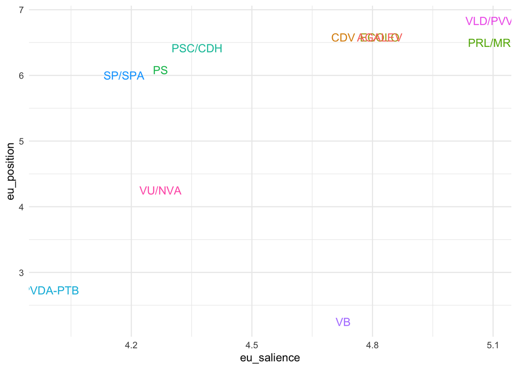

```r
ches %>%
  filter(country == 1) %>% #canvieu el nom del país
  ggplot(aes(x = eu_salience, y = eu_position, col = party)) + #poseu una variable a l'eix de les x i una variable a l'eix de les y
  geom_text(aes(label = party), show.legend = F) +
  theme_minimal()
```

Heu de fer tants eixos com estudiants hi hagi al grup:

- No es poden repetir els eixos.